# Exercise 6

- given the following un-normalized posterior distribution $$ g(\theta |x) \propto \frac{1}{2} \exp{\bigg[-\frac{(\theta + 3)^2}{2}\bigg]} + \frac{1}{2} \exp{\bigg[-\frac{(\theta - 3)^2}{2}\bigg]} $$
- draw a Markov Chain from the posterior distribution using a Metropolis-Hastings algorithm
- use a Norm (0, 1) as random-walk candidate density

```r
# define posterior
test_posterior <- function(theta){
    g <- 0.5 * exp(-(theta+3)^2/2) + 0.5 * exp(-(theta-3)^2/2)
    return(g)
}

theta <- seq(-10, 10, 0.001)
```

```r
# write the metropolis algorithm
metropolis <- function(func, theta.i, n.samples, burn.in){
    theta.now <- theta.i
    func.now <- func(theta.now)
    n <- n.samples + burn.in

    # matrix to see the evolution of the chian
    samples <- matrix(data = NA, nrow = n, ncol = 2)

    # counter
    accepted <- 0

    for(i in 1:n){
        theta.prop <- rnorm(1, theta.now, 1)
        func.prop <- func(theta.prop)
        rho <- func.prop / func.now

        if(rho >= 1 || rho >= runif(1)){
            theta.now <- theta.prop
            func.now <- func.prop
            accepted <- accepted + 1
        }

        samples[i, 1] <- func.now
        samples[i, 2] <- theta.now
    }
    rate <- accepted / n
    print(rate)
    return(samples)
}
```

```r
# running parameters
theta.i <- 0
n.samples <- 10e5
```

```r
# run the chain
set.seed(010623)
chain <- metropolis(test_posterior, theta.i, n.samples, 0)
```

```
[1] 0.710593
```

- plot the sampled distribution

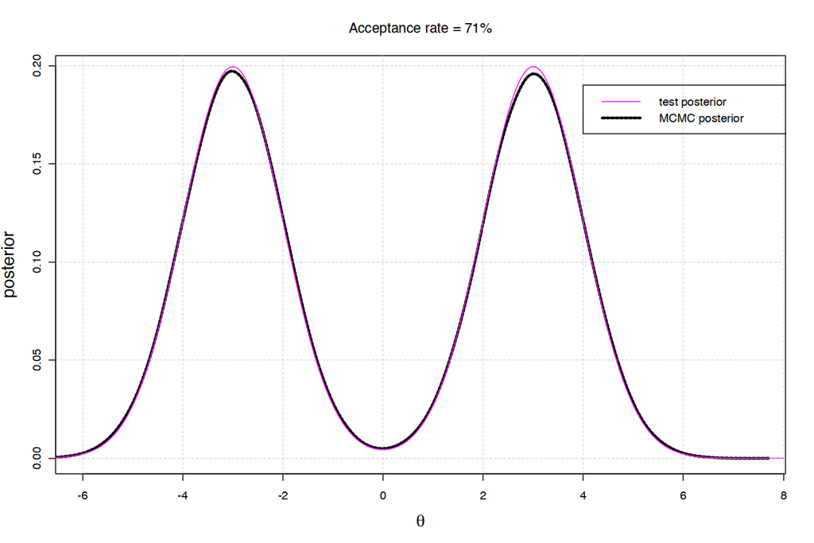

```r
# define the density
postden <- density(chain[, 2], n = 2^10)

# normalize the test posterior
norm_test_posterior <- test_posterior(theta) / integrate(function(theta) test_posterior(theta), -10, 10)$value

# plot
options(repr.plot.width = 12, repr.plot.height = 8)
plot(postden$x, postden$y,
    type = 'l', lty = 2, lwd = 3,
    xlim = c(-6, 7.5),
    xlab = expression(paste(theta)), ylab = 'posterior', cex.lab = 1.5,
    main = "Acceptance rate = 71%")
lines(theta, norm_test_posterior,
    type = 'l', col = 'magenta')
grid(nx = NULL, ny = NULL,
	lty = 2, lwd = 0.5,
	col = 'gray')
legend(4, 0.19,
	legend = c('test posterior', 'MCMC posterior'),
	col = c('magenta', 'black'),
	lty = c(1, 2), lwd = c(1, 3), cex = 1)
```

- analyze the chain with the CODA package and plot the chain autocorrelation

```r
library(coda)
coda_chain <- as.mcmc(chain[, 2])

lags <- seq(0, 1000, 10)
ACF <- autocorr(coda_chain, lags = lags)
eff_size <- effectiveSize(coda_chain)
```

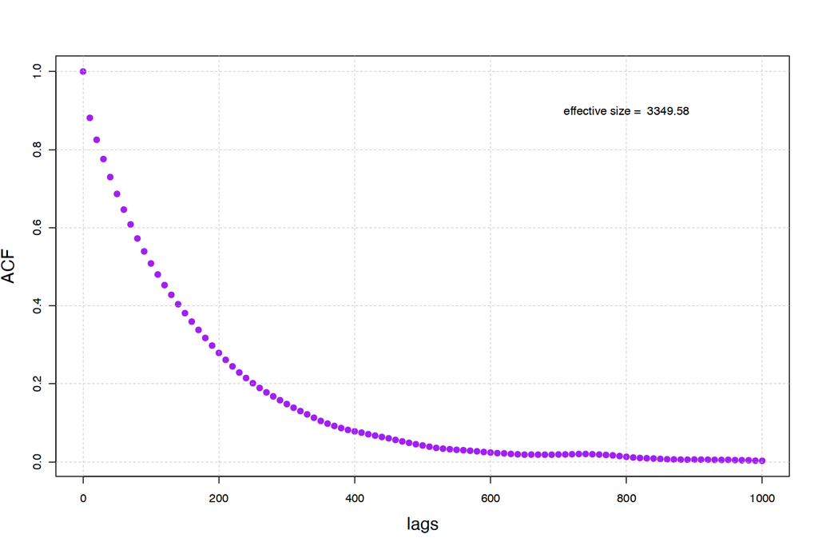

```r
plot(lags, ACF,
    pch = 19, col = 'purple',
    cex.lab = 1.5)
text(800, 0.9,
    paste("effective size = ", round(eff_size, 2)))
grid(nx = NULL, ny = NULL,
	lty = 2, lwd = 0.5,
	col = 'gray')
```

- try to use different burn-in cycles and thinning and plot the corresponding posterior distribution and the chain autocorrelation function. What are the best parameters ?

```r
burn.in <- c(100, 400, 700, 1000)
thin <- c(2, 10, 20, 30)
```

```
[1] 0.710372
[1] 0.7112995
[1] 0.7110123
[1] 0.710983
```

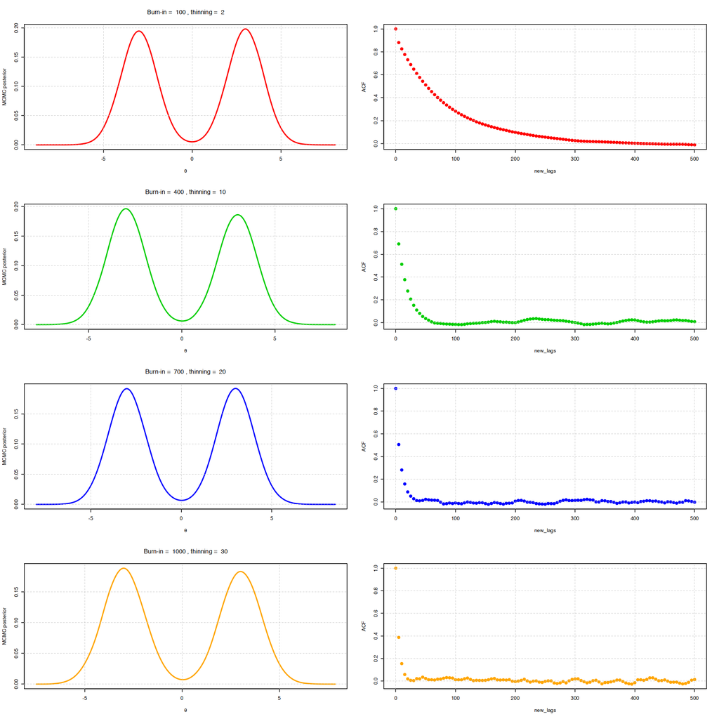

```r
# plot options
options(repr.plot.width = 16, repr.plot.height = 16)
par(mfrow = c(4,2), oma = c(0, 0, 0, 0))
colors = c('red', 'green3', 'blue', 'orange')

new_lags <- seq(0, 500, 5)

for(j in 1:4){
    new_chain <- metropolis(test_posterior, theta.i , n.samples, burn.in[j])

    # thinning the chain
    thin_chain <- new_chain[seq(1, nrow(new_chain), by = thin[j]), ]

    # define the density
    thin_postden <- density(thin_chain[, 2], n = 2^10)

    # analize with CODA
    thin_coda_chain <- as.mcmc(thin_chain[, 2])
    thin_ACF <- autocorr(thin_coda_chain, lags = new_lags)
    eff_size <- effectiveSize(thin_coda_chain)

    plot(thin_postden$x, thin_postden$y,
        type = 'l', lwd = 2,
        col = colors[j],
        xlab = expression(paste(theta)), ylab = 'MCMC posterior',
        main = paste("Burn-in = ", burn.in[j], ", thinning = ", thin[j]))
    grid(nx = NULL, ny = NULL,
	    lty = 2, lwd = 0.5,
	    col = 'gray')
    plot(new_lags, thin_ACF,
        pch = 19, col = colors[j],
        ylab = 'ACF')
    grid(nx = NULL, ny = NULL,
	    lty = 2, lwd = 0.5,
	    col = 'gray')
}
```

Looking at the plots in the right it's clear that the samples are less autocorrelated when we use bigger values of burn-in and thinning

# Exercise 2

- the European Medicines Agency (EMA) has authorized a list of COVID-19 vaccines, after having performed a scientific evaluation of the veccines efficacy
- analyze the initial test data reported on the EMA Web site for the following early Vaccines:
  - Janssen
  - Moderna
  - AstraZeneca

    and create a Markow Chain Monte Carlo JAGS or stan the efficacy of each Vaccine. Infere the 95% credibility interval.

#### Summary table

| Vaccine | Tot vaccinated | Symptomatic with vaccine | Tot placebo | Symptomatic with placebo |
| --- | --- | --- | --- | --- |
| Jannsen | 19630 | 116 | 19691 | 348 |
| Moderna | 14134 | 11 | 14073 | 185 |
| Astrazeneca | 5258 | 64 | 5210 | 154 |

```r
library(rjags)
```

```r
# data jannsen
jan_tot_vacc <- 19630
jan_sym_vacc <- 116
jan_tot_plac <- 19691
jan_sym_plac <- 348

# data moderna
mod_tot_vacc <- 14134
mod_sym_vacc <- 11
mod_tot_plac <- 14073
mod_sym_plac <- 185

# data astrazeneca
astr_tot_vacc <- 5258
astr_sym_vacc <- 64
astr_tot_plac <- 5210
astr_sym_plac <- 154
```

```r
# create 3 tibbles for each vaccine containing the data (0 -> negative, 1 -> positive)
library(tidyverse)
jannsen <- tibble(patient = c(rep("vaccine", jan_tot_vacc),
                                  rep("placebo", jan_tot_plac)),
                    tested = c(rep(1, jan_sym_vacc), rep(0, jan_tot_vacc-jan_sym_vacc),
                                rep(1, jan_sym_plac), rep(0, jan_tot_plac - jan_sym_plac)))

moderna <- tibble(patient = c(rep("vaccine", mod_tot_vacc),
                                  rep("placebo", mod_tot_plac)),
                    tested = c(rep(1, mod_sym_vacc), rep(0, mod_tot_vacc-mod_sym_vacc),
                                rep(1, mod_sym_plac), rep(0, mod_tot_plac - mod_sym_plac)))

astrazeneca <- tibble(patient = c(rep("vaccine", astr_tot_vacc),
                                  rep("placebo", astr_tot_plac)),
                        tested = c(rep(1, astr_sym_vacc), rep(0, astr_tot_vacc-astr_sym_vacc),
                                rep(1, astr_sym_plac), rep(0, astr_tot_plac - astr_sym_plac)))
```

```r
# organize the data in lists for usage in JAGS
jan_list <- list(tested = jannsen$tested,
                patient = as.integer(factor(jannsen$patient)),
                Ntot = jan_tot_vacc + jan_tot_plac)

mod_list <- list(tested = moderna$tested,
                patient = as.integer(factor(moderna$patient)),
                Ntot = mod_tot_vacc + mod_tot_plac)

astr_list <- list(tested = astrazeneca$tested,
                patient = as.integer(factor(astrazeneca$patient)),
                Ntot = astr_tot_vacc + astr_tot_plac)
```

##### Jannsen

```r
#create model
jan_model <- jags.model('ex2.bug', jan_list)
```

```r
# update the MC and print the results
update(jan_model, 1000)
jan_chain <- coda.samples(jan_model, c('theta'), 10^4)
print(summary(jan_chain))
```

```
Iterations = 1001:11000
Thinning interval = 1
Number of chains = 1
Sample size per chain = 10000

1. Empirical mean and standard deviation for each variable,
   plus standard error of the mean:

             Mean        SD  Naive SE Time-series SE
theta[1] 0.017723 0.0009274 9.274e-06      9.274e-06
theta[2] 0.006033 0.0005494 5.494e-06      5.494e-06

2. Quantiles for each variable:

             2.5%      25%      50%      75%    97.5%
theta[1] 0.015966 0.017100 0.017707 0.018342 0.019559
theta[2] 0.005011 0.005662 0.006017 0.006396 0.007159
```

```r
# calculate the efficacy
jan_eff <- (summary(jan_chain)$statistics[1,1] - summary(jan_chain)$statistics[2,1]) / summary(jan_chain)$statistics[1,1]

cat(paste('The Jannsen efficacy is: ', jan_eff))
```

```
The Jannsen efficacy is:  0.659599662173826
```

[figure not shown]

```r
# plot the density
jan_chain_df <- as.data.frame(as.mcmc(jan_chain))

options(repr.plot.width = 16, repr.plot.height = 8)
par(mfrow = c(1,2), oma = c(0, 0, 5, 0))
hist(jan_chain_df[, 1],
    nc = 50, prob = TRUE,
    col = 'greenyellow',
    main = 'Vaccine',
    xlab = expression(paste('Rate ', theta)))
hist(jan_chain_df[, 2],
    nc = 50, prob = TRUE,
    col = 'orange',
    main = 'Placebo',
    xlab = expression(paste('Rate ', theta)))
mtext('Jannsen',
    side = 3, line = 2, outer = TRUE,
    cex = 2)
```

##### Moderna

```r
#create model
mod_model <- jags.model('ex2.bug', mod_list)
```

```r
# update the MC and print the results
update(mod_model, 1000)
mod_chain <- coda.samples(mod_model, c('theta'), 10^4)
print(summary(mod_chain))
```

```
Iterations = 1001:11000
Thinning interval = 1
Number of chains = 1
Sample size per chain = 10000

1. Empirical mean and standard deviation for each variable,
   plus standard error of the mean:

              Mean        SD  Naive SE Time-series SE
theta[1] 0.0132560 0.0009607 9.607e-06      9.607e-06
theta[2] 0.0009837 0.0002612 2.612e-06      2.612e-06

2. Quantiles for each variable:

              2.5%       25%       50%      75%    97.5%
theta[1] 0.0114372 0.0125947 0.0132251 0.013883 0.015248
theta[2] 0.0005429 0.0007955 0.0009635 0.001145 0.001547
```

```r
# calculate the efficacy
mod_eff <- (summary(mod_chain)$statistics[1,1] - summary(mod_chain)$statistics[2,1]) / summary(mod_chain)$statistics[1,1]

cat(paste('The Moderna efficacy is: ', mod_eff))
```

```
The Moderna efficacy is:  0.925795235733461
```

[figure not shown]

```r
# plot the density
mod_chain_df <- as.data.frame(as.mcmc(mod_chain))

options(repr.plot.width = 16, repr.plot.height = 8)
par(mfrow = c(1,2), oma = c(0, 0, 5, 0))
hist(mod_chain_df[, 1],
    nc = 40, prob = TRUE,
    col = 'greenyellow',
    main = 'Vaccine',
    xlab = expression(paste('Rate ', theta)))
hist(mod_chain_df[, 2],
    nc = 50, prob = TRUE,
    col = 'orange',
    main = 'Placebo',
    xlab = expression(paste('Rate ', theta)))
mtext('Moderna',
    side = 3, line = 2, outer = TRUE,
    cex = 2)
```

##### Astrazeneca

```r
#create model
astr_model <- jags.model('ex2.bug', astr_list)
```

```r
# update the MC and print the results
update(astr_model, 1000)
astr_chain <- coda.samples(astr_model, c('theta'), 10^4)
print(summary(astr_chain))
```

```
Iterations = 1001:11000
Thinning interval = 1
Number of chains = 1
Sample size per chain = 10000

1. Empirical mean and standard deviation for each variable,
   plus standard error of the mean:

            Mean       SD  Naive SE Time-series SE
theta[1] 0.02955 0.002337 2.337e-05      2.337e-05
theta[2] 0.01251 0.001531 1.531e-05      1.531e-05

2. Quantiles for each variable:

             2.5%     25%     50%     75%   97.5%
theta[1] 0.025128 0.02794 0.02953 0.03107 0.03428
theta[2] 0.009656 0.01146 0.01248 0.01350 0.01566
```

```r
# calculate the efficacy
astr_eff <- (summary(astr_chain)$statistics[1,1] - summary(astr_chain)$statistics[2,1]) / summary(astr_chain)$statistics[1,1]

cat(paste('The Astrazeneca efficacy is: ', astr_eff))
```

```
The Astrazeneca efficacy is:  0.576573286416014
```

[figure not shown]

```r
# plot the density
astr_chain_df <- as.data.frame(as.mcmc(astr_chain))

options(repr.plot.width = 16, repr.plot.height = 8)
par(mfrow = c(1,2), oma = c(0, 0, 5, 0))
hist(astr_chain_df[, 1],
    nc = 30, prob = TRUE,
    col = 'greenyellow',
    main = 'Vaccine',
    xlab = expression(paste('Rate ', theta)))
hist(astr_chain_df[, 2],
    nc = 45, prob = TRUE,
    col = 'orange',
    main = 'Placebo',
    xlab = expression(paste('Rate ', theta)))
mtext('Astrazeneca',
    side = 3, line = 2, outer = TRUE,
    cex = 2)
```

##### Summary table

[output not shown]

# Exercise 3

- According to the official COVID-19 vaccination data, 70% of the world population has received at least one dose of a COVID-19 vaccine.
- the European Centre for Disease Prevention and Control published a downloadable file containing information on COVID-19 vaccination in the EU/EEA.
- analyze the data and produce the following plots:
  - number of vaccinated people (cumulative, daily and week average)
  - number of confirmed deaths by COVID-19, both cumulative and weekly average

```r
library(dplyr)
library(lubridate)
```

### Vaccinated people

```r
# load the csv file
vacc_table <- read.csv("vaccinations.csv", header = TRUE)
head(vacc_table)
```

A data.frame: 6 × 16

|  | location <chr> | iso_code <chr> | date <chr> | total_vaccinations <dbl> | people_vaccinated <dbl> | people_fully_vaccinated <dbl> | total_boosters <dbl> | daily_vaccinations_raw <int> | daily_vaccinations <int> | total_vaccinations_per_hundred <dbl> | people_vaccinated_per_hundred <dbl> | people_fully_vaccinated_per_hundred <dbl> | total_boosters_per_hundred <dbl> | daily_vaccinations_per_million <int> | daily_people_vaccinated <int> | daily_people_vaccinated_per_hundred <dbl> |
| --- | --- | --- | --- | --- | --- | --- | --- | --- | --- | --- | --- | --- | --- | --- | --- | --- |
| 1 | Afghanistan | AFG | 2021-02-22 | 0 | 0 | NA | NA | NA | NA | 0 | 0 | NA | NA | NA | NA | NA |
| 2 | Afghanistan | AFG | 2021-02-23 | NA | NA | NA | NA | NA | 1367 | NA | NA | NA | NA | 33 | 1367 | 0.003 |
| 3 | Afghanistan | AFG | 2021-02-24 | NA | NA | NA | NA | NA | 1367 | NA | NA | NA | NA | 33 | 1367 | 0.003 |
| 4 | Afghanistan | AFG | 2021-02-25 | NA | NA | NA | NA | NA | 1367 | NA | NA | NA | NA | 33 | 1367 | 0.003 |
| 5 | Afghanistan | AFG | 2021-02-26 | NA | NA | NA | NA | NA | 1367 | NA | NA | NA | NA | 33 | 1367 | 0.003 |
| 6 | Afghanistan | AFG | 2021-02-27 | NA | NA | NA | NA | NA | 1367 | NA | NA | NA | NA | 33 | 1367 | 0.003 |

```r
# Start selecting only the location "World"
vacc_table <- vacc_table[vacc_table$location == 'World', ]
head(vacc_table)
```

A data.frame: 6 × 16

|  | location <chr> | iso_code <chr> | date <chr> | total_vaccinations <dbl> | people_vaccinated <dbl> | people_fully_vaccinated <dbl> | total_boosters <dbl> | daily_vaccinations_raw <int> | daily_vaccinations <int> | total_vaccinations_per_hundred <dbl> | people_vaccinated_per_hundred <dbl> | people_fully_vaccinated_per_hundred <dbl> | total_boosters_per_hundred <dbl> | daily_vaccinations_per_million <int> | daily_people_vaccinated <int> | daily_people_vaccinated_per_hundred <dbl> |
| --- | --- | --- | --- | --- | --- | --- | --- | --- | --- | --- | --- | --- | --- | --- | --- | --- |
| 167702 | World | OWID_WRL | 2020-12-02 | 0 | 0 | NA | NA | 0 | 0 | 0 | 0 | NA | NA | 0 | 0 | 0 |
| 167703 | World | OWID_WRL | 2020-12-03 | 0 | 0 | NA | NA | 1 | 1 | 0 | 0 | NA | NA | 0 | 1 | 0 |
| 167704 | World | OWID_WRL | 2020-12-04 | 1 | 1 | NA | NA | 1 | 1 | 0 | 0 | NA | NA | 0 | 1 | 0 |
| 167705 | World | OWID_WRL | 2020-12-05 | 1 | 1 | NA | NA | 1 | 1 | 0 | 0 | NA | NA | 0 | 1 | 0 |
| 167706 | World | OWID_WRL | 2020-12-06 | 1 | 1 | NA | NA | 1 | 1 | 0 | 0 | NA | NA | 0 | 1 | 0 |
| 167707 | World | OWID_WRL | 2020-12-07 | 2 | 2 | NA | NA | 1 | 1 | 0 | 0 | NA | NA | 0 | 1 | 0 |

```r
# write date column as date
vacc_table$date <- as.Date(vacc_table$date, '%Y-%m-%d')

# add week and year column
vacc_table$week <- week(vacc_table$date)
vacc_table$year <- as.numeric(format(vacc_table$date, '%Y'))

head(vacc_table)
```

A data.frame: 6 × 18

|  | location <chr> | iso_code <chr> | date <date> | total_vaccinations <dbl> | people_vaccinated <dbl> | people_fully_vaccinated <dbl> | total_boosters <dbl> | daily_vaccinations_raw <int> | daily_vaccinations <int> | total_vaccinations_per_hundred <dbl> | people_vaccinated_per_hundred <dbl> | people_fully_vaccinated_per_hundred <dbl> | total_boosters_per_hundred <dbl> | daily_vaccinations_per_million <int> | daily_people_vaccinated <int> | daily_people_vaccinated_per_hundred <dbl> | week <dbl> | year <dbl> |
| --- | --- | --- | --- | --- | --- | --- | --- | --- | --- | --- | --- | --- | --- | --- | --- | --- | --- | --- |
| 167702 | World | OWID_WRL | 2020-12-02 | 0 | 0 | NA | NA | 0 | 0 | 0 | 0 | NA | NA | 0 | 0 | 0 | 49 | 2020 |
| 167703 | World | OWID_WRL | 2020-12-03 | 0 | 0 | NA | NA | 1 | 1 | 0 | 0 | NA | NA | 0 | 1 | 0 | 49 | 2020 |
| 167704 | World | OWID_WRL | 2020-12-04 | 1 | 1 | NA | NA | 1 | 1 | 0 | 0 | NA | NA | 0 | 1 | 0 | 49 | 2020 |
| 167705 | World | OWID_WRL | 2020-12-05 | 1 | 1 | NA | NA | 1 | 1 | 0 | 0 | NA | NA | 0 | 1 | 0 | 49 | 2020 |
| 167706 | World | OWID_WRL | 2020-12-06 | 1 | 1 | NA | NA | 1 | 1 | 0 | 0 | NA | NA | 0 | 1 | 0 | 49 | 2020 |
| 167707 | World | OWID_WRL | 2020-12-07 | 2 | 2 | NA | NA | 1 | 1 | 0 | 0 | NA | NA | 0 | 1 | 0 | 49 | 2020 |

##### Cumulative of vaccinated people

```r
# remove rows with NA in the column "people_vaccinated"
vacc_table_people_vaccinated <- vacc_table[!is.na(vacc_table$people_vaccinated), ]
```

```r
# new tibble with 2 columns: date and total number of vaccinated people
cum_vacc <- vacc_table_people_vaccinated %>% group_by(date) %>% summarise(tot = sum(people_vaccinated))
head(cum_vacc)
```

A tibble: 6 × 2

| date <date> | tot <dbl> |
| --- | --- |
| 2020-12-02 | 0 |
| 2020-12-03 | 0 |
| 2020-12-04 | 1 |
| 2020-12-05 | 1 |
| 2020-12-06 | 1 |
| 2020-12-07 | 2 |

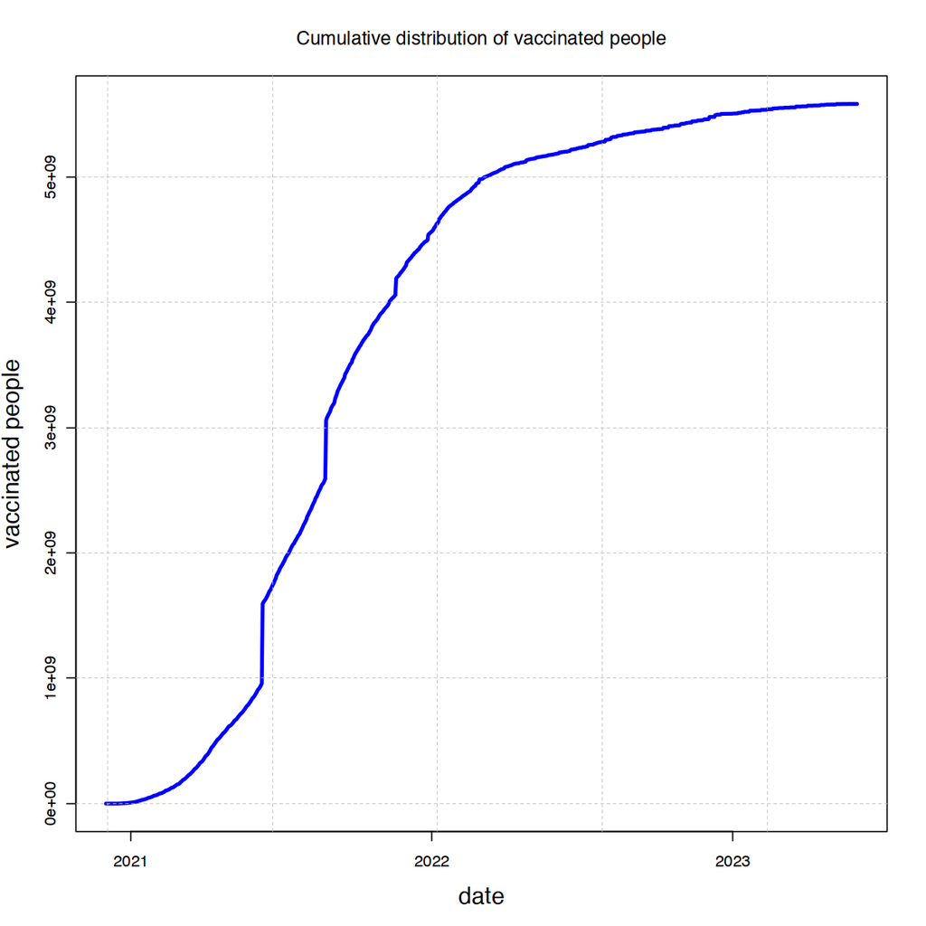

```r
# plot the cumulative distribution of vaccinated people
options(repr.plot.width = 10, repr.plot.height = 10)
plot(cum_vacc$date, cum_vacc$tot,
    type = 'l', lwd = 3,
    col = 'blue',
    xlab = 'date', ylab = 'vaccinated people',
    cex.lab = 1.5,
    main = 'Cumulative distribution of vaccinated people')
grid(nx = NULL, ny = NULL,
	    lty = 2, lwd = 0.5,
	    col = 'gray')
```

##### Daily and week average of vaccinated people

```r
# remove rows with NA in the column "daily vaccinations"
vacc_table_daily <- vacc_table[!is.na(vacc_table$daily_vaccinations), ]

# new tibbles with 2 columns: date and daily/weekly vaccinations
daily_vacc <- vacc_table_daily %>% group_by(date) %>% summarise(tot = sum(daily_vaccinations))
weekly_vacc <- vacc_table_daily %>% group_by(year, week) %>% summarise(tot = mean(daily_vaccinations), .groups = 'drop')

str(daily_vacc)
head(weekly_vacc)
```

```
tibble [906 × 2] (S3: tbl_df/tbl/data.frame)
 $ date: Date[1:906], format: "2020-12-02" "2020-12-03" ...
 $ tot : int [1:906] 0 1 1 1 1 1 1 1 1 1 ...
```

A tibble: 6 × 3

| year <dbl> | week <dbl> | tot <dbl> |
| --- | --- | --- |
| 2020 | 49 | 8.571429e-01 |
| 2020 | 50 | 4.563143e+03 |
| 2020 | 51 | 3.774129e+05 |
| 2020 | 52 | 6.115237e+05 |
| 2020 | 53 | 8.755610e+05 |
| 2021 | 1 | 1.221912e+06 |

```r
# convert number of the week and year into date
weekly_vacc$date <- as.Date(paste(weekly_vacc$year, weekly_vacc$week, 01), "%Y %W %u")
```

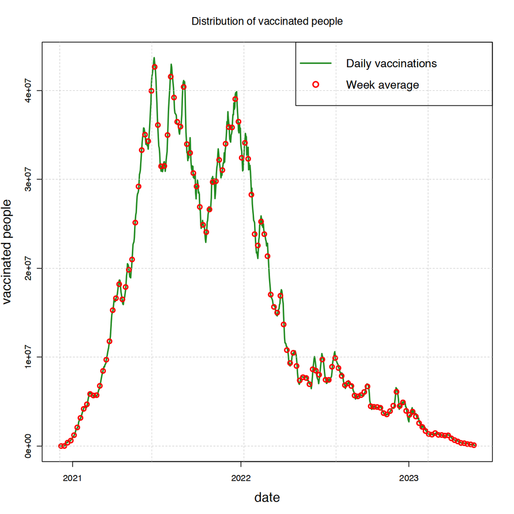

```r
plot(daily_vacc$date, daily_vacc$tot,
    type = 'l', lwd = 2,
	col = 'forestgreen',
	xlab = 'date', ylab = 'vaccinated people',
	cex.lab = 1.5,
	main = 'Distribution of vaccinated people')
points(weekly_vacc$date, weekly_vacc$tot,
	lwd = 2,
	col = 'red')
grid(nx = NULL, ny = NULL,
	    lty = 2, lwd = 0.5,
	    col = 'gray')
legend('topright',
	legend = c('Daily vaccinations', 'Week average'),
	col = c('forestgreen', 'red'),
	lty = c(1, NA), pch = c(NA, 1), lwd = 2, cex = 1.3)
```

### Confirmed deaths

```r
# load the csv files
deaths_table <- read.csv("total_deaths.csv", header = TRUE)
head(deaths_table)

weekly_deaths_table <- read.csv("weekly_deaths.csv", header = TRUE)
head(weekly_deaths_table)
```

A data.frame: 6 × 247

|  | date <chr> | World <dbl> | Afghanistan <dbl> | Africa <dbl> | Albania <dbl> | Algeria <dbl> | American.Samoa <dbl> | Andorra <dbl> | Angola <dbl> | Anguilla <dbl> | ⋯ | Uruguay <dbl> | Uzbekistan <dbl> | Vanuatu <dbl> | Vatican <lgl> | Venezuela <dbl> | Vietnam <dbl> | Wallis.and.Futuna <dbl> | Yemen <dbl> | Zambia <dbl> | Zimbabwe <dbl> |
| --- | --- | --- | --- | --- | --- | --- | --- | --- | --- | --- | --- | --- | --- | --- | --- | --- | --- | --- | --- | --- | --- |
| 1 | 2020-01-03 | NA | NA | NA | NA | NA | NA | NA | NA | NA | ⋯ | NA | NA | NA | NA | NA | NA | NA | NA | NA | NA |
| 2 | 2020-01-04 | NA | NA | NA | NA | NA | NA | NA | NA | NA | ⋯ | NA | NA | NA | NA | NA | NA | NA | NA | NA | NA |
| 3 | 2020-01-05 | NA | NA | NA | NA | NA | NA | NA | NA | NA | ⋯ | NA | NA | NA | NA | NA | NA | NA | NA | NA | NA |
| 4 | 2020-01-06 | NA | NA | NA | NA | NA | NA | NA | NA | NA | ⋯ | NA | NA | NA | NA | NA | NA | NA | NA | NA | NA |
| 5 | 2020-01-07 | NA | NA | NA | NA | NA | NA | NA | NA | NA | ⋯ | NA | NA | NA | NA | NA | NA | NA | NA | NA | NA |
| 6 | 2020-01-08 | NA | NA | NA | NA | NA | NA | NA | NA | NA | ⋯ | NA | NA | NA | NA | NA | NA | NA | NA | NA | NA |

A data.frame: 6 × 247

|  | date <chr> | World <dbl> | Afghanistan <dbl> | Africa <dbl> | Albania <dbl> | Algeria <dbl> | American.Samoa <dbl> | Andorra <dbl> | Angola <dbl> | Anguilla <dbl> | ⋯ | Uruguay <dbl> | Uzbekistan <dbl> | Vanuatu <dbl> | Vatican <dbl> | Venezuela <dbl> | Vietnam <dbl> | Wallis.and.Futuna <dbl> | Yemen <dbl> | Zambia <dbl> | Zimbabwe <dbl> |
| --- | --- | --- | --- | --- | --- | --- | --- | --- | --- | --- | --- | --- | --- | --- | --- | --- | --- | --- | --- | --- | --- |
| 1 | 2020-01-03 | NA | NA | NA | NA | NA | NA | NA | NA | NA | ⋯ | NA | NA | NA | NA | NA | NA | NA | NA | NA | NA |
| 2 | 2020-01-04 | NA | NA | NA | NA | NA | NA | NA | NA | NA | ⋯ | NA | NA | NA | NA | NA | NA | NA | NA | NA | NA |
| 3 | 2020-01-05 | NA | NA | NA | NA | NA | NA | NA | NA | NA | ⋯ | NA | NA | NA | NA | NA | NA | NA | NA | NA | NA |
| 4 | 2020-01-06 | NA | NA | NA | NA | NA | NA | NA | NA | NA | ⋯ | NA | NA | NA | NA | NA | NA | NA | NA | NA | NA |
| 5 | 2020-01-07 | NA | NA | NA | NA | NA | NA | NA | NA | NA | ⋯ | NA | NA | NA | NA | NA | NA | NA | NA | NA | NA |
| 6 | 2020-01-08 | 0 | 0 | 0 | 0 | 0 | 0 | 0 | 0 | 0 | ⋯ | 0 | 0 | 0 | 0 | 0 | 0 | 0 | 0 | 0 | 0 |

```r
# considering only the "World columns", remove the rows with NA
deaths_table <- deaths_table[!is.na(deaths_table$World), 1:2]
head(deaths_table)

weekly_deaths_table <- weekly_deaths_table[!is.na(weekly_deaths_table$World), 1:2]
head(weekly_deaths_table)
```

A data.frame: 6 × 2

|  | date <chr> | World <dbl> |
| --- | --- | --- |
| 10 | 2020-01-12 | 1 |
| 11 | 2020-01-13 | 1 |
| 12 | 2020-01-14 | 1 |
| 13 | 2020-01-15 | 1 |
| 14 | 2020-01-16 | 1 |
| 15 | 2020-01-17 | 2 |

A data.frame: 6 × 2

|  | date <chr> | World <dbl> |
| --- | --- | --- |
| 6 | 2020-01-08 | 0 |
| 7 | 2020-01-09 | 0 |
| 8 | 2020-01-10 | 0 |
| 9 | 2020-01-11 | 0 |
| 10 | 2020-01-12 | 1 |
| 11 | 2020-01-13 | 1 |

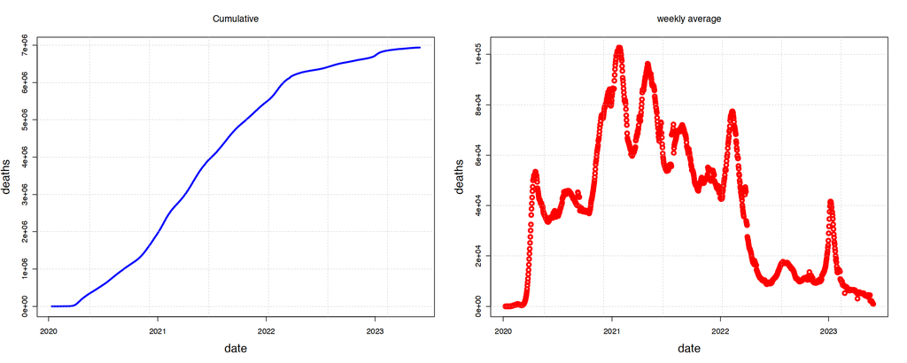

```r
# plots
options(repr.plot.width = 20, repr.plot.height = 8)
par(mfrow = c(1,2), oma = c(0, 0, 0, 0))

plot(as.Date(deaths_table$date), deaths_table$World,
    type = 'l', lwd = 3,
    col = 'blue',
    xlab = 'date', ylab = 'deaths', cex.lab = 1.5,
    main = 'Cumulative')
grid(nx = NULL, ny = NULL,
	    lty = 2, lwd = 0.5,
	    col = 'gray')

plot(as.Date(weekly_deaths_table$date), weekly_deaths_table$World,
    type = 'p', lwd = 3,
    col = 'red',
    xlab = 'date', ylab = 'deaths', cex.lab = 1.5,
    main = 'weekly average')
grid(nx = NULL, ny = NULL,
	    lty = 2, lwd = 0.5,
	    col = 'gray')
```